[RAPID2018](https://rapid2018.org/)

# [RAMP](https://www.ramp.studio/problems/mars_craters) on Primary Vertex reconstruction

1. Introduction
2. Preprocessing
3. Workflow
4. Evaluation
5. Local testing/exploration
6. Submission

## Preprocessing

With no further do, let's have a look at the data.

### Required dependencies and downloads

#### Installation of libraries and `ramp-workflow`

To get this notebook running and test your models locally using the `ramp_test_submission`, we recommend that you use the Python distribution from [Anaconda](https://www.anaconda.com/download/) or [Miniconda](https://conda.io/miniconda.html).

```python
# !conda env create -f environment.yml   # use the environment.yml file to create the 'mars-craters' env
# !source activate mars-craters          # activate the virtual environment
```

**OR** if you have Python already installed but are **not using Anaconda**, you'll want to use `pip`

```python
# !pip install -r requirements.txt
```

#### Download script (optional)

If the data has not yet been downloaded locally, uncomment the following cell and run it.

```python
# !python download_data.py
```

#### The input data

The input data consists of a json file for each event (where an event is a bunch crossing). The json file contains the hits in the Velo detector, Velo states from a simplified Kalman filter of the reconstructed Velo tracks, as well as the MC truth information.

```python
import json
from matplotlib import pyplot as plt
```

```python
jdata = json.load(open('data/train/RapidVPData_6719289_74665.json'))
print (jdata)
```

```
{'EventNumber': 74665, 'MCParticles': {'1001': {'ClosestToBeam': [-0.00011553993668639989, 0.012477663773344829, 35.74091144002617, -1.0978089154474895, -0.01016553334707054, 0.004625256489486849], 'OVPos': [-0.0517, 0.012, 35.7879], 'PV': '620', 'eta': 0.8169220089912415, 'fourMom': [257.3404386884…
```

We are interested in the reconstructed hits and tracks

```python
VeloTracks  = jdata['VeloTracks']
VeloHits  = jdata['VPClusters']
print(VeloTracks)
print(VeloHits)
```

```
{'0': {'ClosestToBeam': [0.004886898594421041, 0.003085980878339001, 56.206748962402344, 0.011977268382906914, -0.01913546212017536, 0.0], 'LHCbIDs': ['2148023507', '2150121437', '2152219111', '2154316785'], 'MCPs': ['2910'], 'errCTBState': [0.009285581751691809, 0.009285581751691809, 1.033285244034…
{'2147550268': {'MCPs': ['2264'], 'key': '2147550268', 'x': 5.038135528564453, 'y': -27.456954956054688, 'z': -288.08099365234375}, '2147610662': {'MCPs': ['2265'], 'key': '2147610662', 'x': -4.995708465576172, 'y': -19.134307861328125, 'z': -288.08099365234375}, '2147615907': {'MCPs': ['5581'], 'ke…
```

The hits are made of (x,y,z) coordinates:

```python
for key, item in VeloHits.items():
    print (item['x'], item['y'], item['z'])
```

[output not shown]

[output cut: 2049 more lines]

[output not shown]

We can, for example, pltos the x-y distribution of all hits:

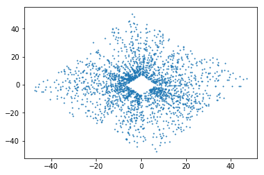

```python
hits_x = [item['x'] for  key, item in VeloHits.items()]
hits_y = [item['y'] for  key, item in VeloHits.items()]
plt.plot(hits_x,hits_y, 'o', markersize=1.)
```

or z distribution

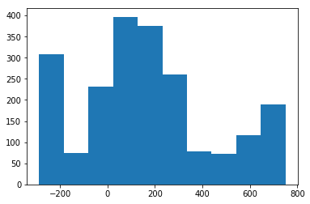

```python
hits_z = [item['z'] for  key, item in VeloHits.items()]
plt.hist(hits_z)
```

For submitting at the [RAMP site](http://ramp.studio), you will have to write an `ObjectDetector` class in a file named `object_detector.py` that will handle the training and prediction .

### Object detector

Format of the data it receives:

```python
import problem
```

```python
X, y = problem.get_train_data('.')
```

```
Rec data
```

```python
X.shape
```

```
(6,)
```

```python
print(X)
```

```
[EventData EventData EventData EventData EventData EventData]
```

There are a couple of helper classes to illustrate how the data is organized. The test and train data X is a numpy array of object of type EventData. Let' have a closer look at this helper class:

```python
event = X[0]
```

It contains the two members, hits and tracks, which are lists containing the Velo hits and states, respectively, again using helper classes:

```python
event.hits
```

```
[VeloHit(9.393913269042969, -26.134666442871094, -288.08099365234375),
 VeloHit(9.0050048828125, -24.579030990600586, -288.08099365234375),
 VeloHit(-0.38714027404785156, -14.097940444946289, -288.08099365234375),
 VeloHit(-0.38714027404785156, -13.514577865600586, -288.08099365234375),
 VeloHit(-7.1735992431640625, -16.59343719482422, -288.08099365234375),
 VeloHit(-7.815296173095703, -16.820301055908203, -288.08099365234375),
 VeloHit(-2.9150466918945312, -11.258907318115234, -288.08099365234375),
 VeloHit(-2.7983760833740234, -5.891963958740234, -288.08099365234375),
 VeloHit(-3.051166534423828, -5.989192962646484, -288.08099365234375),
 VeloHit(-4.898479461669922, -7.330928802490234, -288.08099365234375),
 VeloHit(-7.640287399291992, -3.344615936279297, -288.08099365234375),
 VeloHit(-6.706905364990234, -1.2445068359375, -288.08099365234375),
 VeloHit(-7.653251647949219, -1.5167465209960938, -288.08099365234375),
 VeloHit(-16.69478988647461, -21.35816192626953, -286.91900634765625),
 VeloHit(-9.003236770629883, 11.74327564239502, -286.91900634765625),
 VeloHit(-8.497655868530273, 7.659734725952148, -286.91900634765625),
 VeloHit(-4.978031635284424, 2.506692886352539, -286.91900634765625),
 VeloHit(-12.639533996582031, 9.934850692749023, -286.91900634765625),
 VeloHit(-12.561752319335938, 9.779287338256836, -286.91900634765625),
 VeloHit(-11.317243576049805, 7.679180145263672, -286.91900634765625),
 VeloHit(-11.414470672607422, 7.504171371459961, -286.91900634765625),
 VeloHit(-6.6503400802612305, 1.8455486297607422, -286.91900634765625),
 VeloHit(-13.417350769042969, 5.656854629516602, -286.91900634765625),
 VeloHit(-14.681304931640625, -4.007526397705078, -286.91900634765625),
 VeloHit(-43.36332702636719, -2.588010787963867, -288.08099365234375),
 VeloHit(-40.29094696044922, -2.801910877227783, -288.08099365234375),
 VeloHit(-31.365489959716797, 6.298553943634033, -288.08099365234375),
 VeloHit(-31.20992660522461, 6.376335620880127, -288.08099365234375),
 VeloHit(-34.554542541503906, 10.576549530029297, -288.08099365234375),
 VeloHit(-25.609642028808594, 11.393259048461914, -288.08099365234375),
 VeloHit(-12.42740249633789, 25.82353973388672, -275.58099365234375),
 VeloHit(-5.563162803649902, 26.69858169555664, -275.58099365234375),
 VeloHit(4.159553527832031, 11.531143188476562, -275.58099365234375),
 VeloHit(4.781808853149414, 5.036365509033203, -275.58099365234375),
 VeloHit(5.423505783081055, 5.328052520751953, -275.58099365234375),
 VeloHit(11.723831176757812, 5.250267028808594, -275.58099365234375),
 VeloHit(7.718070983886719, 0.933380126953125, -275.58099365234375),
 VeloHit(5.716958045959473, -11.80161190032959, -274.41900634765625),
 VeloHit(2.1584434509277344, -5.248499870300293, -274.41900634765625),
 VeloHit(2.6056880950927734, -5.475363731384277, -274.41900634765625),
```

[output cut: 946 more lines]

```
 VeloHit(-13.378460884094238, -5.349262237548828, 488.08099365234375),
 VeloHit(-16.820302963256836, -6.5743255615234375, 488.08099365234375),
 VeloHit(-24.170677185058594, -4.590890884399414, 488.08099365234375),
 VeloHit(-27.845863342285156, -5.427043914794922, 488.08099365234375),
 VeloHit(-39.27978515625, -7.916060447692871, 486.91900634765625),
 VeloHit(-27.04860496520996, 12.28774642944336, 486.91900634765625),
 VeloHit(-21.059410095214844, 15.243452072143555, 486.91900634765625),
 VeloHit(-11.941266059875488, 34.08784866333008, 499.41900634765625),
 VeloHit(-9.64670467376709, 34.28230285644531, 499.41900634765625),
 VeloHit(-12.81631088256836, 26.056884765625, 499.41900634765625),
 VeloHit(-5.077027797698975, 16.373056411743164, 499.41900634765625),
 VeloHit(0.6010398864746094, 16.606403350830078, 499.41900634765625),
 VeloHit(4.178998947143555, 19.328763961791992, 499.41900634765625),
 VeloHit(-1.440730094909668, 12.153396606445312, 499.41900634765625),
 ...]
```

```python
event.tracks
```

```
[VeloState(-0.014058536488221307,-0.024329251519816353,-20.015792846679688,0.0337035171687603,-0.04416502267122269),
 VeloState(0.04143393940914564,0.03616156003867843,155.3652801513672,0.01934237591922283,-0.017269106581807137),
 VeloState(0.5647286828943905,-0.37778717743778856,92.0198745727539,0.009444397874176502,0.01475947443395853),
 VeloState(-0.01761487652828464,0.013645172620613266,67.32335662841797,-0.09499440342187881,0.05916781723499298),
 VeloState(-0.04450437906444904,0.007529980805301761,-21.103111267089844,0.09429869055747986,-0.06211370974779129),
 VeloState(0.00644126462086092,0.020223739698650434,-18.137502670288086,-0.07876195013523102,0.07210911810398102),
 VeloState(-0.07139266851731918,0.1239037813328423,-17.093446731567383,-0.08104813098907471,0.071827232837677),
 VeloState(-0.0731509079913053,0.03437391877928064,-19.428049087524414,-0.087270587682724,0.05691782385110855),
 VeloState(-0.041670922641060315,-0.08042012593523395,151.45184326171875,-0.37878137826919556,0.043419379740953445),
 VeloState(-0.15907703169983733,-0.00880906886625965,-16.152141571044922,-0.13724438846111298,0.015338295139372349),
 VeloState(-0.5694452883874419,0.8155024380073712,-9.556892395019531,-0.14206235110759735,0.006350761279463768),
 VeloState(0.02132300063385628,0.04033879998178236,151.48890686035156,0.1629009246826172,-0.2932533919811249),
 VeloState(-0.05322216759466869,-0.020088640442850192,-20.613971710205078,-0.04687190800905228,0.13584181666374207),
 VeloState(0.6033949158033352,-0.5268431957567543,46.83582305908203,0.02409639209508896,0.048172418028116226),
 VeloState(-0.04732300652904087,-0.0017686330152173468,66.71341705322266,0.11985611915588379,0.13933596014976501),
 VeloState(-0.9107782017509294,0.5198064071682893,39.611515045166016,0.08039028942584991,0.14541196823120117),
 VeloState(-0.09810488480772506,0.054505719451555024,-19.308666229248047,-0.09081212431192398,0.11036809533834457),
 VeloState(0.020477516375876803,0.02892042393150973,-18.709148406982422,-0.131197988986969,0.09366225451231003),
 VeloState(0.02752647563220023,-0.0016108721381442592,-20.28915023803711,-0.055584993213415146,-0.1648140549659729),
 VeloState(0.05724610128951646,0.025245384333970833,-18.630970001220703,0.007104349322617054,0.21147722005844116),
 VeloState(-0.03847276393661048,0.059324492456660494,-18.13560676574707,-0.19728006422519684,0.07247727364301682),
 VeloState(-0.19817756066925085,-0.15588443283260034,-17.16122055053711,-0.2288287878036499,-0.09264148026704788),
 VeloState(0.013663112771951091,-0.019074210231138977,-18.466264724731445,-0.12063920497894287,0.24711516499519348),
 VeloState(-0.029756522859997858,0.03927512956527579,-18.891786575317383,0.35929426550865173,-0.0019725030288100243),
 VeloState(-0.33243619250910683,0.15275812066963113,76.4654769897461,0.018756266683340073,0.04591529443860054),
 VeloState(-0.005174633389401606,-0.009277655511795047,-18.603736877441406,0.28226083517074585,0.09703494608402252),
 VeloState(0.03985716338763723,-0.020700510971465746,-18.811386108398438,0.14654189348220825,0.19963355362415314),
 VeloState(0.007313107593148516,0.12860972464883957,-20.858476638793945,-0.29967549443244934,-0.1459430754184723),
 VeloState(0.02012301642215597,-0.041254810216692306,-18.803977966308594,0.21641863882541656,0.21524876356124878),
 VeloState(-0.05518908926011079,-0.32725367009810213,-5.101259231567383,0.11014454811811447,-0.023640044033527374),
 VeloState(-0.0018524545842666384,0.14878458507521408,-10.807311058044434,0.11303012073040009,-0.022196268662810326),
 VeloState(-0.00928712392012443,0.03688067239925896,-21.395769119262695,0.02864186093211174,0.0058383033610880375),
 VeloState(-1.2823998848325573,0.3083993692733884,142.70062255859375,0.0034804344177246094,0.014385548420250416),
 VeloState(0.5078988184678792,0.17493820301484675,159.9306182861328,-0.01984214037656784,0.058733079582452774),
 VeloState(0.07145805690480977,0.00034429151120463075,-8.158736228942871,0.0015432427171617746,0.04823712259531021),
 VeloState(0.10503360168900144,-0.022965936879700166,158.32574462890625,0.006803714204579592,0.02518400177359581),
 VeloState(-0.14634684240905926,0.6898743354489199,-16.452068328857422,-0.18980781733989716,-0.03719339147210121),
 VeloState(-0.13544530164563184,0.674393898464885,-16.42369270324707,-0.1896195411682129,-0.03735274821519852),
 VeloState(0.10983642940394134,0.03944429132531013,-18.001567840576172,0.06322293728590012,-0.1690061241388321),
 VeloState(-0.04607351957929495,0.0651437352225912,66.91252899169922,0.22401873767375946,0.16760008037090302),
```

[output cut: 90 more lines]

```
 VeloState(-0.02706364093046254,0.14066411236862564,-18.719667434692383,-0.013312590308487415,0.07197512686252594),
 VeloState(-0.022830589374535748,-0.05161231867025151,-20.81376838684082,-0.01829056441783905,0.06622498482465744),
 VeloState(-0.04392317894827613,0.1266364074853925,-16.165424346923828,-0.041289541870355606,0.029925636947155),
 VeloState(-0.015710651726834612,-0.04802994246270487,-17.344650268554688,0.035551536828279495,-0.04776390269398689),
 VeloState(0.1321477206626973,-0.08895996289670194,-9.234418869018555,0.018066590651869774,0.025977667421102524),
 VeloState(0.019873554663035975,0.03577162991587102,151.400634765625,-0.03415548428893089,0.09766592085361481),
 VeloState(-0.043323324162429344,-0.0016736356928390705,-18.421310424804688,-0.053288280963897705,0.024227388203144073),
 VeloState(-0.001651539630984189,0.06932639094748083,-18.89179229736328,-0.07774035632610321,-0.015728900209069252),
 VeloState(0.8248780317533146,-2.2002605544707876,75.5608901977539,0.10236772894859314,0.043440401554107666),
 VeloState(0.06353700800906381,0.029586477077714335,151.72251892089844,0.047899942845106125,0.12236861139535904),
 VeloState(0.06726960967574058,-0.15899693753550537,-15.946748733520508,0.026611465960741043,-0.10157546401023865),
 VeloState(-0.12533520219267302,-0.05293417575876447,151.68443298339844,0.11765351891517639,-0.13053444027900696),
 VeloState(0.9023151860804717,-0.3137080962195675,-9.39284896850586,0.12172291427850723,-0.008174185641109943),
 VeloState(-0.054776537869429376,-0.03982063758232357,-21.585941314697266,0.05206090211868286,0.08228237181901932),
 VeloState(0.03760860568119284,0.009032575359753992,-18.741313934326172,0.01566103659570217,0.11036865413188934)]
```

The VeloHit class just holds the x,y,z coordinates of the hit:

```python
hit = event.hits[0]
print (hit)
print(hit.x, hit.y, hit.z)
```

```
VeloHit(9.393913269042969, -26.134666442871094, -288.08099365234375)
9.393913269042969 -26.134666442871094 -288.08099365234375
```

The VeloTrack helper class holds the state (x,y,z,tx,ty,p/q) of a simplified Kalman fit of the track, as well as the corresponding covariance matrix:

```python
track = event.tracks[0]
print(track)
print("track state:")
print("x:", track.x)
print("y:", track.y)
print("z:", track.z)
print("tx:", track.tx)
print("ty:", track.ty)
print("pq:", track.pq)

print("covariance matrix:")
print("cov x:", track.cov_x)
print("cov y:", track.cov_y)
print("cov tx:", track.cov_tx)
print("cov ty:", track.cov_ty)
print("cov xtx:", track.cov_xtx)
```

```
VeloState(-0.014058536488221307,-0.024329251519816353,-20.015792846679688,0.0337035171687603,-0.04416502267122269)
track state:
x: -0.014058536488221307
y: -0.024329251519816353
z: -20.015792846679688
tx: 0.0337035171687603
ty: -0.04416502267122269
pq: 0.0
covariance matrix:
cov x: 0.00149062710342775
cov y: 0.00149062710342775
cov tx: 5.936173863574368e-08
cov ty: 5.936173863574368e-08
cov xtx: 8.931202236391695e-06
```

again, we can make plots:

```python
hits_x = [hit.x for hit in event.hits]
hits_y = [hit.y for hit in event.hits]
hits_z = [hit.z for hit in event.hits]
```

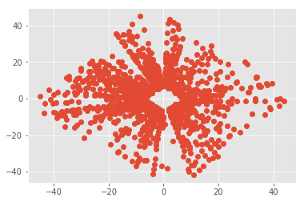

```python
plt.plot(hits_x, hits_y, 'o')
```

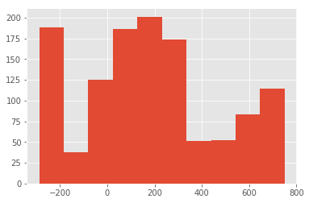

```python
plt.hist(hits_z)
```

It should be noted that the p/q is always zero, since we have no momentum estimate from the Velo Kalman fit. The covariance matrix consist of the diagonal elements x, y, tx, ty and the off-diagonal element xtx. The Velo Kalman fit contains some simplifications, resulting that the covariance element for x and y is always equal. The same is true for the xtx and yty elements